# Ford Go Bike Trip Analysis

## Chris Manning

## Preliminary Wrangling

> This project is an exploratory analysis of Ford GoBike trip data for the month of February in 2019

## Project Introduction

### What is the structure of your dataset?

- trip duration
- start/end time
- starting station id, name, lattitude & longitude
- ending station id, name, lattitude & longitude
- bike id
- user type
- member birth year, gender, age
- bike share for all

### What is/are the main feature(s) of interest in your dataset?

> i'm most interested in understanding how factors such as age, gender, usertype affect trip duration

### What features in the dataset do you think will help support your investigation into your feature(s) of interest?

> duration_sec

## Univariate Exploration

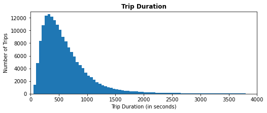

```python
# plot histogram to show trip duration distribution
binsize = np.arange(0, 5000, 50)
plt.figure(figsize=[8, 3])
plt.hist(data = df_clean, x = 'duration_sec', bins = binsize)
plt.axis([0, 4000, 0, 13000])
plt.title("Trip Duration", fontweight='semibold')
plt.xlabel("Trip Duration (in seconds)")
plt.ylabel("Number of Trips")
plt.show()
```

```python
print(round((((len(df_clean.query("duration_sec < 300")) / df_clean.shape[0]))*100)), "percent of trips are less than 5 minutes long")
print(round((((len(df_clean.query("duration_sec < 600")) / df_clean.shape[0]))*100)), "percent of trips are less than 10 minutes long")
print(round((((len(df_clean.query("duration_sec < 900")) / df_clean.shape[0]))*100)), "percent of trips are less than 15 minutes long")
print(round((((len(df_clean.query("duration_sec < 1800")) / df_clean.shape[0]))*100)), "percent of trips are less than 30 minutes long")
print("the average trip length is", round((df_clean['duration_sec']/60).mean()), "minutes long")
```

```
22 percent of trips are less than 5 minutes long
60 percent of trips are less than 10 minutes long
81 percent of trips are less than 15 minutes long
97 percent of trips are less than 30 minutes long
the average trip length is 12 minutes long
```

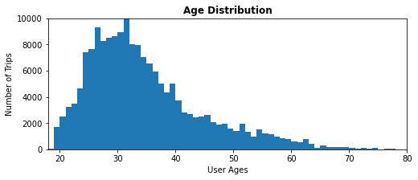

```python
# plot histogram to show user age distribution
binsize = np.arange(0, 5000, 1)
plt.figure(figsize=[8, 3])
plt.hist(data = df_clean, x = 'age', bins = binsize)
plt.axis([18, 80, 0, 10000])
plt.title("Age Distribution", fontweight='semibold')
plt.xlabel("User Ages")
plt.ylabel("Number of Trips")
plt.show()
```

```python
print(round((((len(df_clean.query("age < 40")) / df_clean.shape[0]))*100),2), "percent of users under 40 years old")
print("the user age is", round((df_clean['age']).mean(),0), "years old")
print("the minimum user age is", df_clean['age'].min())
print("the maximum user age is", df_clean['age'].max(), "- all ages over 80 were removed")
```

```
76.86 percent of users under 40 years old
the user age is 34.0 years old
the minimum user age is 18
the maximum user age is 80 - all ages over 80 were removed
```

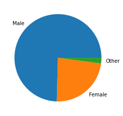

```python
# plot pie chart to show user gender distribution
labels = 'Male', 'Female', 'Other'
plt.pie(df_clean.member_gender.value_counts(), labels = labels)
plt.show()
```

```python
print(len(df_clean.query("member_gender == 'Male'")), " males account for", round((len(df_clean.query("member_gender == 'Male'")) / df_clean.shape[0]) * 100), "percent of all users")
print(len(df_clean.query("member_gender == 'Female'")), "females account for", round((len(df_clean.query("member_gender == 'Female'")) / df_clean.shape[0]) * 100), "percent of all users")
print(len(df_clean.query("member_gender == 'Other'")), "other gender account for", round((len(df_clean.query("member_gender == 'Other'")) / df_clean.shape[0]) * 100), "percent of all users")
```

```
130345  males account for 75 percent of all users
40771 females account for 23 percent of all users
3644 other gender account for 2 percent of all users
```

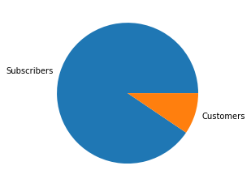

```python
# plot pie chart to show user gender distribution
labels = 'Subscribers',  'Customers'
plt.pie(df_clean.user_type.value_counts(), labels = labels)
plt.show()
```

```python
print(len(df_clean.query("user_type == 'Customer'")), " customers account for", round((len(df_clean.query("user_type == 'Customer'")) / df_clean.shape[0]) * 100), "percent of all users")
print(len(df_clean.query("user_type == 'Subscriber'")), "Subscribers account for", round((len(df_clean.query("user_type == 'Subscriber'")) / df_clean.shape[0]) * 100), "percent of all users")
```

```
16557  customers account for 9 percent of all users
158203 Subscribers account for 91 percent of all users
```

[figure not shown]

```python
#create new column to display day of the week
df_clean['day']=df_clean['start_time'].dt.strftime('%A')

#create variables for bar chart
x = df_clean.day.unique()
y = df_clean.day.value_counts()

#create bar chart to show usage by day
plt.figure(figsize=[8, 3])
plt.bar(x,y)
plt.title("Most Popular Usage Days", fontweight='semibold')
plt.ylabel("Number of Trips")
plt.show()
```

```python
print("the middle of the week, tuesday-thursday, are the busiest days.", "these days account for", round(((len(df_clean.query("day == 'Tuesday'"))+len(df_clean.query("day == 'Wednesday'"))+len(df_clean.query("day == 'Thursday'")))/df_clean.shape[0])*100), "percent of the trips")
print(round(((len(df_clean.query("day == 'Thursday'")))/df_clean.shape[0])*100), "percent of the trips are Thursday")
print(round(((len(df_clean.query("day == 'Monday'"))+len(df_clean.query("day == 'Tuesday'"))+len(df_clean.query("day == 'Wednesday'"))+len(df_clean.query("day == 'Thursday'"))+len(df_clean.query("day == 'Friday'")))/df_clean.shape[0])*100), "percent of the trips are on a weekday")
print(round(((len(df_clean.query("day == 'Saturday'"))+len(df_clean.query("day == 'Sunday'")))/df_clean.shape[0])*100), "percent of the trips are on a weekend")
```

```
the middle of the week, tuesday-thursday, are the busiest days. these days account for 53 percent of the trips
19 percent of the trips are Thursday
83 percent of the trips are on a weekday
17 percent of the trips are on a weekend
```

```python
print('number of trips per day of the week')
df_clean.day.value_counts()
```

```
number of trips per day of the week
```

```
Thursday     33691
Tuesday      30562
Wednesday    28396
Friday       27621
Monday       25588
Sunday       14492
Saturday     14410
Name: day, dtype: int64
```

### Discuss the distribution(s) of your variable(s) of interest. Were there any unusual points? Did you need to perform any transformations?

> Did not see any unusual points. I did create new columns to make analysis easier
> - Age: subtracted 2019 from member_birth_year to get user age
> - Day: extracted the day of the week from the start_time column

### Of the features you investigated, were there any unusual distributions? Did you perform any operations on the data to tidy, adjust, or change the form of the data? If so, why did you do this?¶

> Items cleaned
> - Age: Removed any customers over 80 years old assuming these were errors
> - NULLs: Removed all rows with NULL values in start_station_id, end_station_id, member_birth_year, member_gender
> - Datatypes: Changed several datatypes to make data analysis easier

## Bivariate Exploration

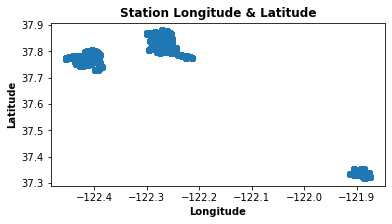

```python
#scatterplot of station locations
fig = plt.figure(figsize=(6,3))
plt.scatter(data = df_clean, x = 'start_station_longitude', y = 'start_station_latitude')
plt.title('Station Longitude & Latitude', fontweight='semibold')
plt.xlabel('Longitude', fontweight='semibold')
plt.ylabel('Latitude', fontweight='semibold')

plt.show()
```

Here we've mapped out our station locations via longitude & latitude. This shows three major location clusters.  
The two clusters at the top-left are about 0.15 degrees apart (roughly 7-10 miles)  
The clusters the bottom right is about 0.4 degrees away from the other two (roughly 30 miles away)

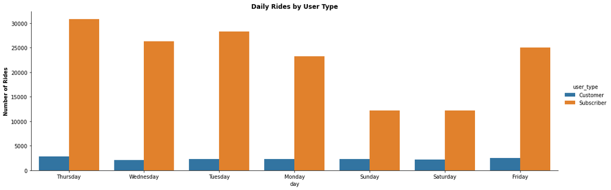

```python
sns.catplot(data=df_clean, x='day', hue='user_type', kind='count', aspect=12/4)
plt.title('Daily Rides by User Type', fontweight='semibold')
plt.ylabel('Number of Rides', fontweight='semibold')

plt.show()
```

There are 10x more subscribers than there are customers.  
We can see a definitive trend of daily riders with the subscriber group  
Due to the smaller size of the customer base its difficult to determine daily usage trends

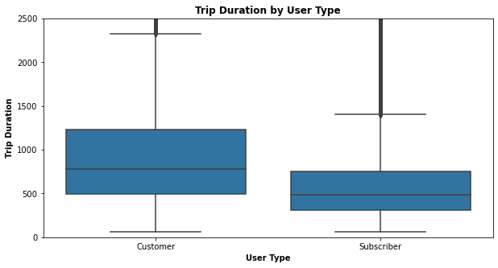

```python
base_color = sns.color_palette()[0]
plt.figure(figsize = [10, 5])
sns.boxplot(data = df_clean, x = 'user_type', y = 'duration_sec', color=base_color)
plt.ylim([0,2500])
plt.title('Trip Duration by User Type', fontweight='semibold')
plt.xlabel('User Type', fontweight='semibold')
plt.ylabel('Trip Duration', fontweight='semibold')
plt.show()
```

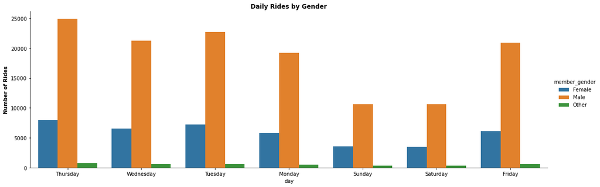

```python
sns.catplot(data=df_clean, x='day', hue='member_gender', kind='count', aspect=12/4)
plt.title('Daily Rides by Gender', fontweight='semibold')
plt.ylabel('Number of Rides', fontweight='semibold')
plt.show()
```

Male & Female riders follow a similar daily pattern as the number of rides ebb and flow on the same days.  
Other gender is difficult to analyze as their overall ride numbers are so much less than males & females. We can see a small drop on the weekends but the weekday rides appear flat

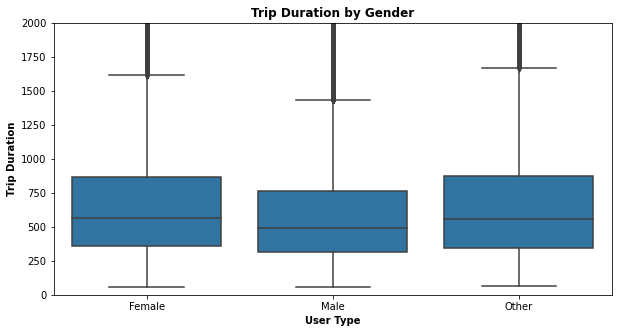

```python
base_color = sns.color_palette()[0]
plt.figure(figsize = [10, 5])
sns.boxplot(data = df_clean, x = 'member_gender', y = 'duration_sec', color=base_color)
plt.ylim([0,2000])
plt.title('Trip Duration by Gender', fontweight='semibold')
plt.xlabel('User Type', fontweight='semibold')
plt.ylabel('Trip Duration', fontweight='semibold')
plt.show()
```

Male riders lag behind females & other gender in duration

- Males average the shortest trips of all genders
- The longest trips by males are shorter than the longest trips of other & females

### Talk about some of the relationships you observed in this part of the investigation. How did the feature(s) of interest vary with other features in the dataset?

> - **Station Locations**: Stations are physically located in three geographical clusters
> - **User Type**: Subscribers daily patterns mirror the same distributions as genders. Customer usage seems flatter across each day. However, customers take much longer trips than subscribers.
> - **Member Gender**: All genders seem to have similar daily ride patterns. Males have the shortest durations compared to female and other genders.

### Did you observe any interesting relationships between the other features (not the main feature(s) of interest)?

> I was suprised to see that the weekends are the least popular days for riders. I was expecting to see the opposite considering that overall drip durations are short (under 30 minutes) and most people run errands on the weekends.

## Multivariate Exploration

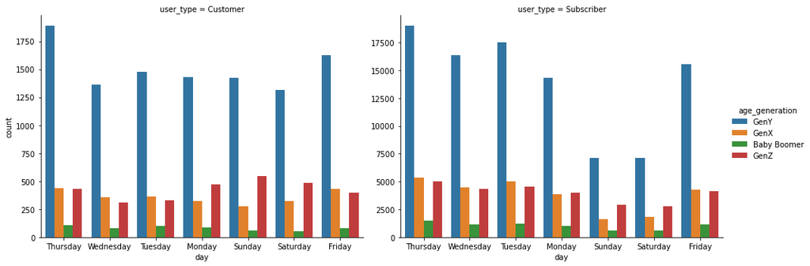

```python
# daily rides per user type by age group
sns.catplot(data=df_clean, x='day', col="user_type", hue='age_generation', kind='count', aspect=20/15,
                 sharey=False)
plt.show()
```

Subscribers are responsible for the drop off in volume over the weekend.  
This could be broken down futher to see that the majority of this drop off is due to the GenY subscribers These drops are also seen in GenX & GenZ subscribers though they dont have the same overall volume

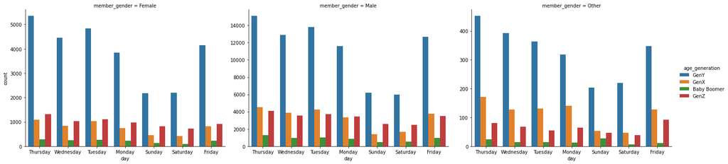

```python
# daily rides per gender by age group
sns.catplot(data=df_clean, x='day', col="member_gender", hue='age_generation', kind='count', aspect=20/15,
                 sharey=False)
plt.show()
```

The drop off in weekend volume is consistent across all genders.  
There is an oddity in other gender trips on Tuesday as it does not follow the same upward trend from males & females

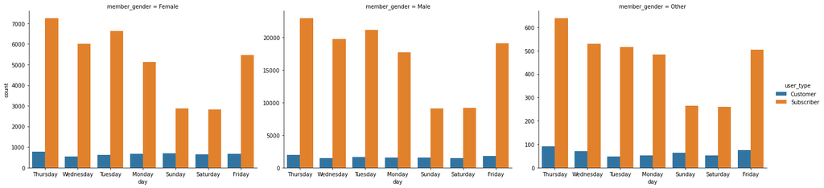

```python
# daily rides per gender by user type
sns.catplot(data=df_clean, x='day', col="member_gender", hue='user_type', kind='count', aspect=20/15,
                 sharey=False)
plt.show()
```

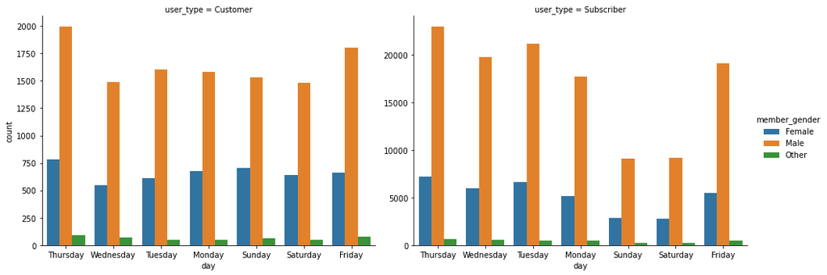

```python
# daily rides per user type by gender
sns.catplot(data=df_clean, x='day', col="user_type", hue='member_gender', kind='count', aspect=20/15,
                 sharey=False)
plt.show()
```

Male subscribers usage drops significantly on the weekends, further than with females or other genders  
Male customers have less day-to day variation between saturday - wednesday then male subscribers  
it is still difficult to assess the usage of other gender (customers or subscribers) due to the lack of size

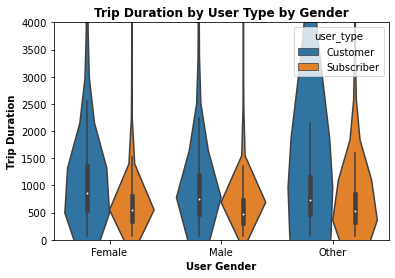

```python
sns.violinplot(data = df_clean, x = 'member_gender', y = 'duration_sec', hue = 'user_type', scale="width")
plt.ylim([0,4000])
plt.title('Trip Duration by User Type by Gender', fontweight='semibold')
plt.xlabel('User Gender', fontweight='semibold')
plt.ylabel('Trip Duration', fontweight='semibold')
plt.show()
```

The average trip duration is higher for customers of all genders compared to subscriber durations  
These violin plots for the customers are longer and wider than the subscriber plots

### Talk about some of the relationships you observed in this part of the investigation. Were there features that strengthened each other in terms of looking at your feature(s) of interest?

> **Weekend Usage**: This helped to understand which groups are responsible for weekend usage

> ```
> - GenY: this group takes by far the most trips, but their volume drastically declines on the weekends
> - Males & Females: make up the majority of riders.  both groups decline in usage on the weekends
> - Subscribers: again, the majority of riders, sees a decline on weekends
> ```

### Were there any interesting or surprising interactions between features?

> I did not find any surprises in the data to note

```python
jupyter nbconvert explanatory_analysis_slides.ipynb --to slides --post serve --template output_toggle
```

[output not shown]